# US Severe Weather Health & Economic Impacts

Peter Sedivec

Saturday, December 20, 2014

# 1 Synopsis

In this report we look at storms and other severe weather events and their public health impact and economic consequences for communities and municipalities. The raw data used in this analysis was the U.S. National Oceanic and Atmospheric Administration’s (NOAA) storm database. The analysis showed that the most harmful to population health (as measured by fatalities and injuries) on an aggregate level were Tornados. There were roughly 60K tornados recorded the and number of fatalities and injuries was an order of magnitude greater than the next most harmful event type. When looking at what event type was most harmful on average per event the top event types were: Extreme Heat, Wild Fires, Heat Waves and Tsunamis. When looking at the event type with greatest economic consequence Tornados were once again at the top of the list, however when looking at greatest average economic consequence on a “per event” basis it highlighted a flaw in the analysis because 16 of the top 25 events were single events (e.g. named hurricanes). This lead to the conclusion that further analysis is really required to consolidate the Event Types and produce a more complete picture regarding economic consequence.

# 2 Data Processing

The first step in data processing was to load required packages for analysis

[output not shown]

After the required packages were loaded the data was downloaded, unzipped and then loaded into R

```r
setwd("~/GitHub/datasciencecoursera/RepData")
bzFile <- "./data/StormData.csv.bz2"
sdFile <- gsub(".bz2","",bzFile)

# If we don't have data, create directory, download and unzip it
if (!file.exists("data")) {
    dir.create("data")
    fileURL<- "https://d396qusza40orc.cloudfront.net/repdata%2Fdata%2FStormData.csv.bz2"
    download.file(fileURL, destfile = bzFile)
    bunzip2(bzFile, sdFile, remove = FALSE)  # Extract file from bz2
    }

# read the data in and view overall statistics about it
sd <- read.csv(sdFile)
# str(sd) # loop at the data structure
# summary(sd) # look at a sumamry of the statistics
```

After loading the data and doing some preliminary exploration it was determined that a few cleaning steps would improve the analysis. Specifically Event Type we want to characterize. Event type has duplicates based on case (e.g. Volcanic Ash and VOLCANIC ASH) and plurals (e.g. WILDFIRE and WILDFIRES). There were other similarities that could have been applied to improve the data but these were the most glaring. I also took advantage of cleaning up the PROPDMGEXP and CROPDMGEXP. The variables harmful and costly were created to summarize the population harm and economic consequence by Event Type

```r
# create an exponent function to calculate the magnitude of the reported crop/property damage (thousands, millions, billions)
exp <- function (f) if (f == 'K') 1e3 else if (f == 'M') 1e6 else if (f == 'B') 1e9 else 1

# convert all the EventType names to uppercase and strip off plural "s", clean-up PROPDMGEXP and COPDMGEXP so they're all upper-case factors and convert values to $ by creating propDmg and cropDmg functions
sdCleaned <- mutate(sd, EVTYPE = sub("S$","",toupper(EVTYPE)), PROPDMGEXP = toupper(PROPDMGEXP), CROPDMGEXP = toupper(CROPDMGEXP), propDmg = PROPDMG*exp(PROPDMGEXP), cropDmg = CROPDMG*exp(CROPDMGEXP))
# summarize by EventType and count total Fatalities & Injuries
harmful <- ddply(sdCleaned, .(EVTYPE), summarize, count = length(EVTYPE), totFat = sum(FATALITIES),
                 totInj = sum(INJURIES), totHarm = totFat+totInj, .drop=FALSE)

# summarize by EventType and count total property and crop damage
costly <- ddply(sdCleaned, .(EVTYPE), summarize, count = length(EVTYPE),
                totPropDmg = sum(propDmg), totCropDmg = sum(cropDmg))
```

# 3 Analysis

## 3.1 Harmful to Population

The first step in the analysis was determining what “harmful” meant given the measured variables in the dataset. I decided that loss of life (fatality) was 10x more important than an injury so I computed a harmFac variable where fatalities were weighted 10x injuries and I used that to compute perEvent to actually indicate the harmFac score per # of Event occurences. I subsetted the data to only contain Event Types where the # of fatalities and/or injuries were greater than 50. The data frames I used contained the following columns: 1. EVTYPE - type of Event, from original dataset 2. count - occurence of a given event 3. totFat - total # of fatalities for EVTYPE 4. totInj - total # of injuries for EVTYPE 5. totHarm - totFat + totInj 6. harmFac - harm factor = 10 x (totFat) + totInj (weighted harm index that says a fatality is 10x worse than an injury) 7. perEvent - average harmFac per Event (harmFac / count)

```r
# subset and look for the most harmful by total injuries/fatalities
MostHarmful <-subset(harmful, totFat>50 | totInj>50)

# adding a harmful Factor which weights fatalities to be 10x injuries and also
# calculates a perEvent harmful Index
MostHarmful <-mutate(MostHarmful, harmFac = 10*totFat+totInj, perEvent = round(harmFac/count,1))

# look at top 15 by Harmful Factor
TopHarmful <- head(MostHarmful[order(-MostHarmful$harmFac),],15)

# look at top 15 as viewed by per Event Harmful Factor
TopPerEvent <- head(MostHarmful[order(-MostHarmful$perEvent),],15)
```

## 3.2 Greatest Economic Consequence

```r
# add a totDmg variable that represents the combined property and crop damage
costly <- mutate(costly, totDmg = totPropDmg+totCropDmg, perEvent = totDmg/count)

# create a list of the most expensive event types in aggregate
TopCostly <- head(costly[order(-costly$totDmg),],25)

# create a dataframe with the top most expensive on a "per Event" basis
TopCostPerEvent <- head(costly[order(-costly$perEvent),],25)
```

# 4 Results

## 4.1 Most Harmful to Population Health

Interpretting and answering the question “which types of events are most harmful with respect to population health?” can be interpretted in two main ways: * As an aggregate which event type is most harmful (independent of how many event occurences) * On a per Event basis which Event types are the most harmful

Below is a tabular representation of both most harmful in aggregate and most harmful per Event

```r
head(TopHarmful)
```

```
##             EVTYPE  count totFat totInj totHarm harmFac perEvent
## 724        TORNADO  60653   5633  91346   96979  147676      2.4
## 112 EXCESSIVE HEAT   1678   1903   6525    8428   25555     15.2
## 397      LIGHTNING  15754    816   5230    6046   13390      0.8
## 744      TSTM WIND 219948    504   6957    7461   11997      0.1
## 133    FLASH FLOOD  54309    980   1777    2757   11577      0.2
## 148          FLOOD  25330    470   6789    7259   11489      0.5
```

```r
head(TopPerEvent)
```

```
##                EVTYPE count totFat totInj totHarm harmFac perEvent
## 123      EXTREME HEAT    22     96    155     251    1115     50.7
## 834         WILD FIRE     4      3    150     153     180     45.0
## 230         HEAT WAVE    77    177    379     556    2149     27.9
## 764           TSUNAMI    20     33    129     162     459     22.9
## 352 HURRICANE/TYPHOON    88     64   1275    1339    1915     21.8
## 112    EXCESSIVE HEAT  1678   1903   6525    8428   25555     15.2
```

We can also look at this graphically, and examine the total harm by events. This graphically shows that Tornados are without question the most harmful in terms of population health with close to 6,000 fatalities and over 90,000 injuries

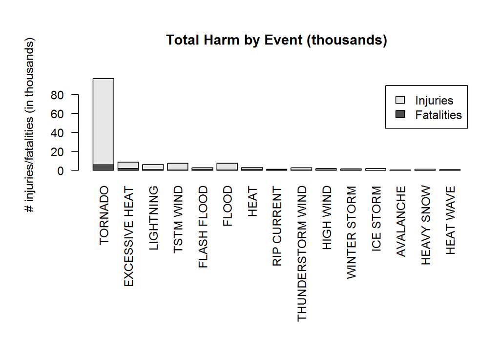

```r
par(las=2, mai=c(2.5,1,1,0.25)+0.1)
barplot(t(data.matrix(subset(TopHarmful, select=c(3,4))))/1000, names.arg = TopHarmful$EVTYPE, legend.text=c("Fatalities","Injuries"),main="Total Harm by Event (thousands)", ylab="# injuries/fatalities (in thousands)")
```

Looking at a per Event basis we see a different picture which shows that Heat is actually the most dangerous relative to population health

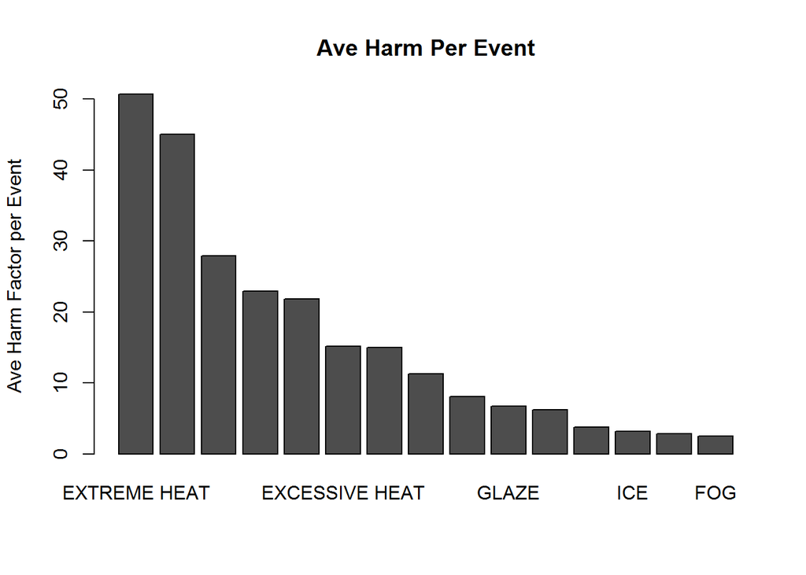

```r
barplot(t(data.matrix(subset(TopPerEvent, select=c(7)))), names.arg = TopPerEvent$EVTYPE, main="Ave Harm Per Event", ylab="Ave Harm Factor per Event")
```

## 4.2 Greatest Economic Consequence

Looking at the greatest economic consequence table in aggregate shows that Tornados are the most damaging Event Type in aggregate (there were also over 60,000 recorded that factored into the total cost

```r
TopCostly
```

```
##                   EVTYPE  count totPropDmg totCropDmg     totDmg  perEvent
## 724              TORNADO  60653 3212258160  100018.52 3212358179 52962.890
## 133          FLASH FLOOD  54309 1421760190  179200.46 1421939390 26182.389
## 744            TSTM WIND 219948 1336054610  109202.60 1336163813  6074.908
## 657    THUNDERSTORM WIND 103407 1323137350   85476.38 1323222826 12796.260
## 148                FLOOD  25330  900943480  168087.88  901111568 35574.874
## 199                 HAIL 288661  688693380  579596.28  689272976  2387.829
## 397            LIGHTNING  15754  603351780    3580.61  603355361 38298.550
## 301            HIGH WIND  21747  380356560   19042.81  380375603 17490.946
## 847         WINTER STORM  11436  133220590    2478.99  133223069 11649.446
## 256           HEAVY SNOW  15708  122251990    2165.72  122254156  7782.923
## 836             WILDFIRE   2769   85059340    4864.20   85064204 30720.189
## 367            ICE STORM   2006   66000670    1688.95   66002359 32902.472
## 576          STRONG WIND   3773   64227800    1621.90   64229422 17023.435
## 238           HEAVY RAIN  11768   53137190   11682.80   53148873  4516.390
## 737       TROPICAL STORM    690   48423680    5899.12   48429579 70187.796
## 835     WILD/FOREST FIRE   1458   39364950    4201.54   39369152 27002.162
## 144       FLASH FLOODING    682   28497150    5126.05   28502276 41792.194
## 802 URBAN/SML STREAM FLD   3392   26051940    2793.80   26054734  7681.230
## 28              BLIZZARD   2719   25318480     172.00   25318652  9311.751
## 571          STORM SURGE    261   19393490       5.00   19393495 74304.579
## 154    FLOOD/FLASH FLOOD    625   19153250    1427.70   19154678 30647.484
## 379            LANDSLIDE    608   19066940      37.00   19066977 31360.160
## 343            HURRICANE    174   15513680    5339.31   15519019 89189.766
## 375     LAKE-EFFECT SNOW    636   14141000       0.00   14141000 22234.277
## 503          RIVER FLOOD    173   13855700    3490.00   13859190 80110.925
```

When examining the data on a “per Event” basis it’s clear that more detailed analysis probably needs to be completed to get the true picture in answering the economic consequence question (either in aggregate or on a per Event basis). The reason for this is because in looking at the table below, of the top 25 most costly on a per Event basis, 16 were single events and upon further inspection of the data we see several hurricane’s that are labeled uniquely.

```r
TopCostPerEvent
```

```
##                             EVTYPE count totPropDmg totCropDmg  totDmg
## 46                 COASTAL EROSION     1     766000          0  766000
## 239           HEAVY RAIN AND FLOOD     1     600000          0  600000
## 502         RIVER AND STREAM FLOOD     2    1200000          0 1200000
## 740          TROPICAL STORM GORDON     1     500000        500  500500
## 36           BLIZZARD/WINTER STORM     1     500000          0  500000
## 138                   FLASH FLOOD/     1     500000          0  500000
## 146 FLASH FLOODING/THUNDERSTORM WI     1     500000          0  500000
## 159              FLOOD/RIVER FLOOD     1     500000          0  500000
## 180                  FROST\\FREEZE     1     500000          0  500000
## 248                HEAVY RAIN/SNOW     1     500000          0  500000
## 281        HEAVY SNOW/WINTER STORM     1     500000          0  500000
## 315                  HIGH WIND/SEA     1     500000          0  500000
## 349               HURRICANE GORDON     1     500000          0  500000
## 522                SLEET/ICE STORM     1     500000          0  500000
```

[output cut: 37 more lines]

# 5 Further Analysis

Unfortunately it’s not a trivial exercise to continue to clean-up the data and consolidate the EventTypes into a more manageable set. For example, we can look at unique Event Types and then look at all of those with the name Tornado or Hurricane. We’ll see that we can’t just search for the unique name (e.g. Hurricane and/or Tornado) to further clean our dataset because some of those occurances contain other weather event types (e.g. HIGH WINDS, WATERSPOUT)

```r
eTypes<-unique(sd$EVTYPE)
eTypes[grep("TORNADO", eTypes)]
```

```
##  [1] TORNADO                    TORNADO F0
##  [3] TORNADOS                   WATERSPOUT/TORNADO
##  [5] WATERSPOUT TORNADO         WATERSPOUT-TORNADO
##  [7] TORNADOES, TSTM WIND, HAIL COLD AIR TORNADO
##  [9] WATERSPOUT/ TORNADO        TORNADO F3
## [11] TORNADO F1                 TORNADO/WATERSPOUT
## [13] TORNADO F2                 TORNADOES
## [15] TORNADO DEBRIS
## 985 Levels:    HIGH SURF ADVISORY  COASTAL FLOOD ... WND
```

```r
eTypes[grep("HURRICANE", eTypes)]
```

```
## [1] HURRICANE OPAL/HIGH WINDS  HURRICANE ERIN
## [3] HURRICANE OPAL             HURRICANE
## [5] HURRICANE-GENERATED SWELLS HURRICANE EMILY
## [7] HURRICANE GORDON           HURRICANE FELIX
## [9] HURRICANE/TYPHOON
## 985 Levels:    HIGH SURF ADVISORY  COASTAL FLOOD ... WND
```

The last comment I’ll make is that upon further inspection of the different event types it was clear that the list could greatly be reduced, as an example, if we look at all the event types containing the word WINTER we notice a lot of similarity. Further consolidation of event types could impact the analysis and decisions regarding where to allocate funding

```r
eTypes[grep("WINTER", eTypes)]
```

```
##  [1] WINTER STORM            WINTER STORM/HIGH WIND
##  [3] WINTER STORM/HIGH WINDS WINTER STORM HIGH WINDS
##  [5] WINTER STORMS           WINTER WEATHER
##  [7] HEAVY SNOW/WINTER STORM BLIZZARD/WINTER STORM
##  [9] WINTER MIX              WINTERY MIX
## [11] WINTER WEATHER MIX      WINTER WEATHER/MIX
## 985 Levels:    HIGH SURF ADVISORY  COASTAL FLOOD ... WND
```